# UCAS - example EXACT output (CompSci)

```r
library(tidyverse)
library(ggvis)
```

# UCAS - example EXACT output (CompSci)

## Data import

Data downloaded from https://www.ucas.com/data-and-analysis/data-products-and-services/exact

“This covers English, Welsh, and Northern Irish domiciled 18 year old applicants applying to computer science courses, who are recorded as achieving the equivalent of ABB grades or above in their best three A levels, between 2013 and 2017. The dimension variables are A level points. The statistics are applications, offers, and acceptances, reported for five cycles.”

```r
df <- read_csv("data/exact_000000.csv", skip = 12, col_names = TRUE)   # exclude explanation rows
```

[output not shown]

```r
df
```

| Entry Year | Achieved A level point score | Number of Applications | Number of Offers as-at 30 June | Number of Acceptances |
| --- | --- | --- | --- | --- |
| 2013-2014 | 1 point | 735 | 615 | 135 |
| 2013-2014 | 2 points | 1385 | 1175 | 260 |
| 2013-2014 | 3 points | 1500 | 1295 | 280 |
| 2013-2014 | 4 points | 1820 | 1585 | 350 |
| 2013-2014 | 5 points | 1895 | 1675 | 325 |
| 2013-2014 | 6 points | 1970 | 1790 | 390 |
| 2013-2014 | 7 points | 2285 | 2030 | 440 |
| 2013-2014 | 8 points | 2435 | 2215 | 470 |
| 2013-2014 | 9 points | 2535 | 2325 | 510 |
| 2013-2014 | 10 points | 2315 | 2145 | 450 |

[output cut: 85 more lines]

These are not ‘UCAS Tariff Points’ by any definition I can find between 2013 and 2018. The current UCAS Tariff Calculator gives 128 points for ABB grades (48+40+40), whereas the dataset has 18 points as maximum!

The “PDF format example” explains that `A*`=6, A=5, B=4 and “These scores are calculated purely for analytical purposes and do not relate to the UCAS tariff”. `A*A*A*` would then be 18 points (the max) and ABB would be 13 points, (so how are there applicants with 1-12 points?)

## Data cleaning : Headings

```r
# shortening the headers and removing spaces
df <- df %>% dplyr::rename(Entry_Year = `Entry Year`, ALevel_points = `Achieved A level point score`, Applications = `Number of Applications`, Offers = `Number of Offers as-at 30 June`, Acceptances = `Number of Acceptances`)
df
```

| Entry_Year | ALevel_points | Applications | Offers | Acceptances |
| --- | --- | --- | --- | --- |
| 2013-2014 | 1 point | 735 | 615 | 135 |
| 2013-2014 | 2 points | 1385 | 1175 | 260 |
| 2013-2014 | 3 points | 1500 | 1295 | 280 |
| 2013-2014 | 4 points | 1820 | 1585 | 350 |
| 2013-2014 | 5 points | 1895 | 1675 | 325 |
| 2013-2014 | 6 points | 1970 | 1790 | 390 |
| 2013-2014 | 7 points | 2285 | 2030 | 440 |
| 2013-2014 | 8 points | 2435 | 2215 | 470 |
| 2013-2014 | 9 points | 2535 | 2325 | 510 |
| 2013-2014 | 10 points | 2315 | 2145 | 450 |

[output cut: 85 more lines]

## Data cleaning : rows

```r
# Keep only the number from 'ALevel_points'. That field then sorts ok on a chart axis
# "No A levels held" gets converted to "NA", so change that to "0" instead
df <- df %>% mutate(ALevel_points = parse_number(ALevel_points)) %>%
  mutate(ALevel_points = replace(ALevel_points,is.na(ALevel_points),0))
```

[output not shown]

```r
df
```

| Entry_Year | ALevel_points | Applications | Offers | Acceptances |
| --- | --- | --- | --- | --- |
| 2013-2014 | 1 | 735 | 615 | 135 |
| 2013-2014 | 2 | 1385 | 1175 | 260 |
| 2013-2014 | 3 | 1500 | 1295 | 280 |
| 2013-2014 | 4 | 1820 | 1585 | 350 |
| 2013-2014 | 5 | 1895 | 1675 | 325 |
| 2013-2014 | 6 | 1970 | 1790 | 390 |
| 2013-2014 | 7 | 2285 | 2030 | 440 |
| 2013-2014 | 8 | 2435 | 2215 | 470 |
| 2013-2014 | 9 | 2535 | 2325 | 510 |
| 2013-2014 | 10 | 2315 | 2145 | 450 |

[output cut: 85 more lines]

Could use `stringr` and a regular expression to extract the number (instead of using `parse_number()`). But would then need to load `stringr`, because it isn’t part of the core `tidyverse`

## Basic EDA

```r
df %>% count(Entry_Year)                    # 5 rows (19 of each)
```

| Entry_Year | n |
| --- | --- |
| 2013-2014 | 19 |
| 2014-2015 | 19 |
| 2015-2016 | 19 |
| 2016-2017 | 19 |
| 2017-2018 | 19 |

```r
df %>% count(Applications)                  # 89 rows
```

| Applications | n |
| --- | --- |
| 390 | 1 |
| 500 | 1 |
| 505 | 1 |
| 555 | 1 |
| 590 | 1 |
| 670 | 1 |
| 680 | 1 |
| 695 | 1 |
| 735 | 1 |
| 785 | 2 |

[output cut: 79 more lines]

```r
df %>% count(Applications) %>% count(n)     # 3 rows (ie. some 'duplications' in 95 rows. Not relevant)
```

| n | nn |
| --- | --- |
| 1 | 84 |
| 2 | 4 |
| 3 | 1 |

```r
df %>% filter(is.na(ALevel_points))         # 0 rows
```

| Entry_Year | ALevel_points | Applications | Offers | Acceptances |
| --- | --- | --- | --- | --- |

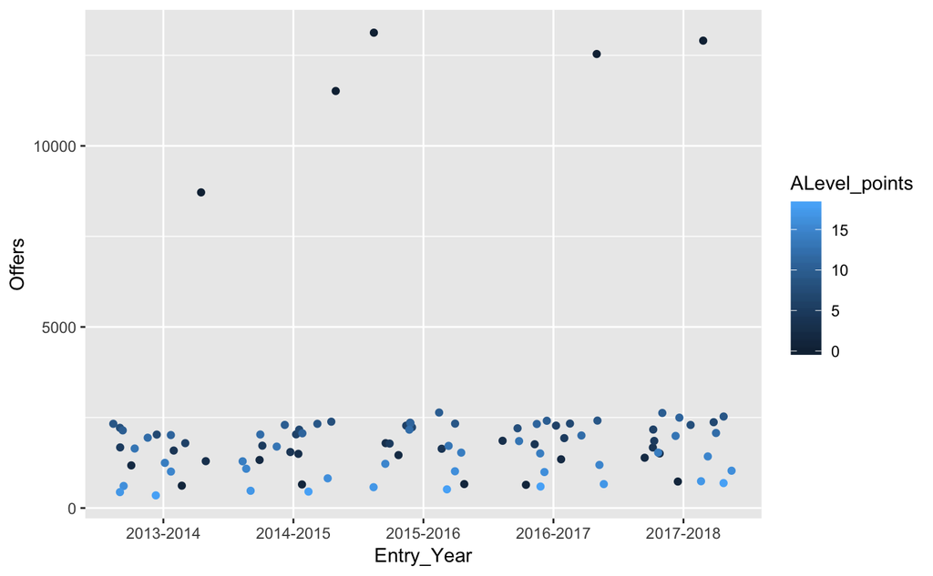

```r
#1
df %>%
  ggplot(aes(Entry_Year, Offers, colour = ALevel_points)) +
  geom_jitter()
```

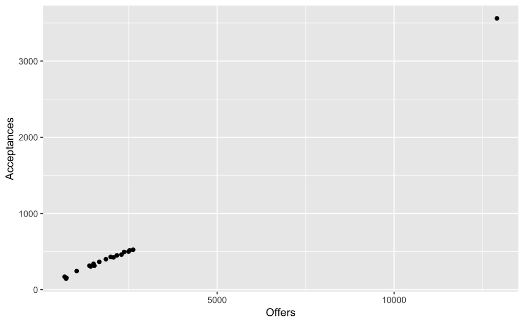

```r
#2
df %>% filter(Entry_Year == "2017-2018") %>%
#  filter(ALevel_points != "No A levels held") %>%
  ggplot(aes(Offers, Acceptances)) +
  geom_point()
```

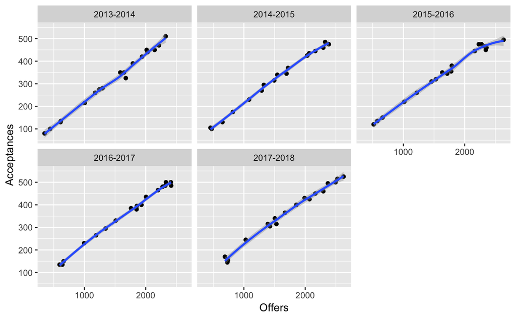

```r
#3
df %>% filter(ALevel_points != 0) %>%
  ggplot(aes(Offers, Acceptances)) +
  geom_point() +
  geom_smooth() +
  facet_wrap(~ Entry_Year)
```

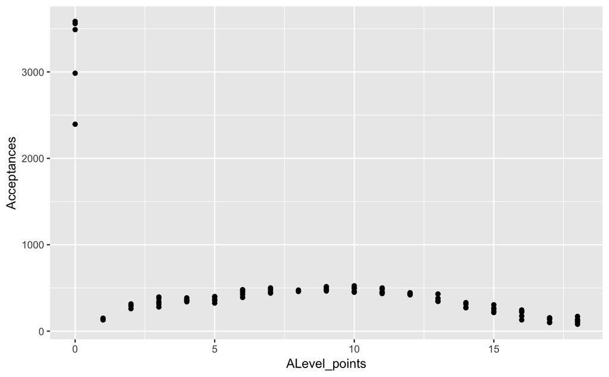

```r
#4
df %>%
#  filter(ALevel_points != "No A levels held") %>%
  ggplot(aes(ALevel_points, Acceptances)) +
  geom_point()
```

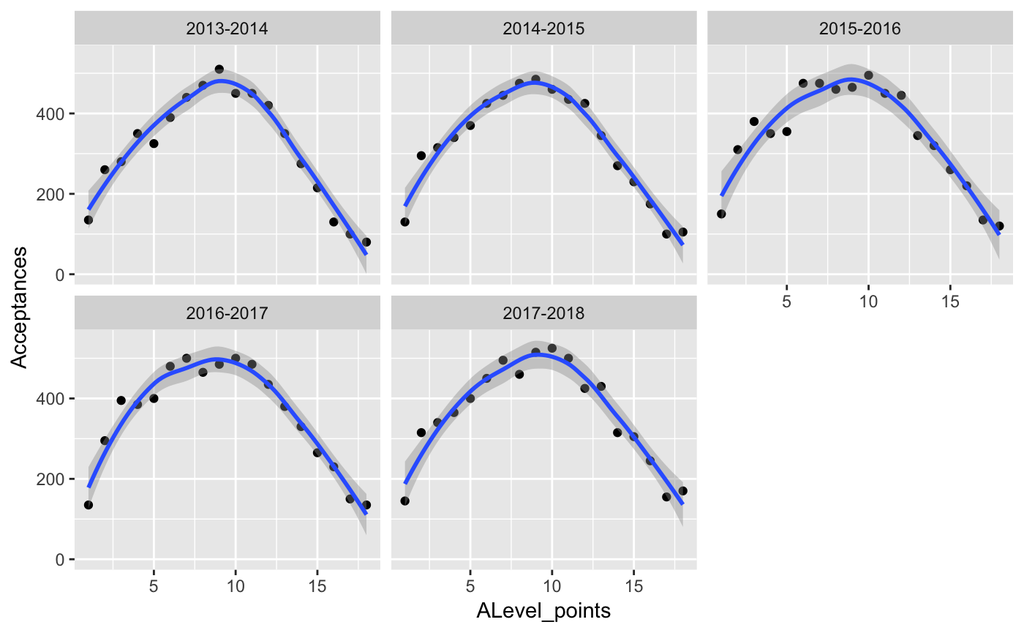

```r
#5
df %>% filter(ALevel_points != 0) %>%
  ggplot(aes(ALevel_points, Acceptances)) +
  geom_point() +
  geom_smooth() +
  facet_wrap(~ Entry_Year)
```

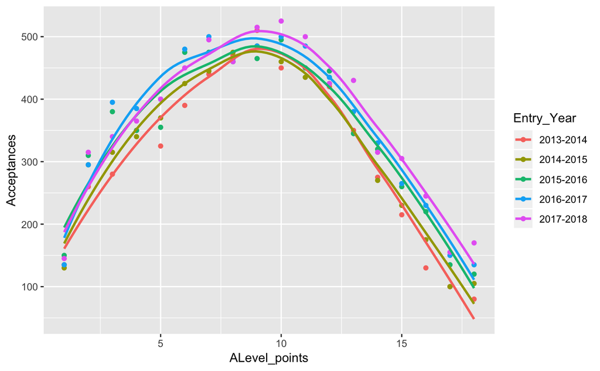

```r
#6
df %>% filter(ALevel_points != 0) %>%
  ggplot(aes(ALevel_points, Acceptances, colour = Entry_Year)) +
  geom_point() +
  geom_smooth(se = FALSE)
```

NOTE : Unable to knit current version of Rmd file (to share corrected charts, etc in html). Yesterday (3/3/19) it knit a first version ok. Now I get “Error: pandoc version 1.12.3 or higher is required and was not found” …which is an old issue (so don’t understand why it worked yesterday). 17/3/19 Tried “Clear Knitr Cache…” and then knit